# Estatística no R

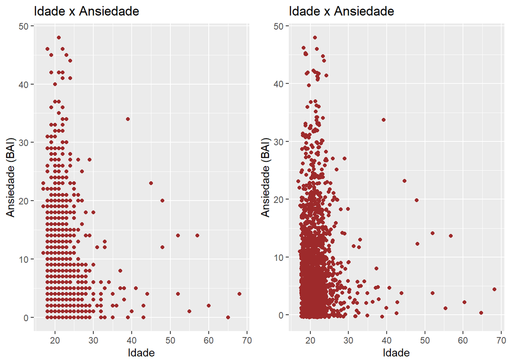

```r
# colocar os dois gráficos juntos na mesma imagem

gridExtra::grid.arrange(

  #Gráfico 1

  ggplot(dataset, aes(x=age, y=bai_sum)) +
  geom_point(color = "#9e2a2b") +
  labs(title = "Idade x Ansiedade",
       x = "Idade", y = "Ansiedade (BAI)"),

  # Gráfico 2
ggplot(dataset, aes(x=age, y=bai_sum)) +
  geom_jitter(color = "#9e2a2b") +
  labs(title = "Idade x Ansiedade",
       x = "Idade", y = "Ansiedade (BAI)"),
nrow = 1    # sem esse comando, os gráficos ficam 2 linhas
)
```

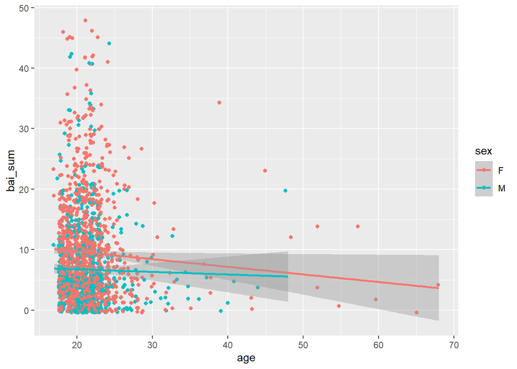

```r
dataset %>%
filter(!is.na(sex)) %>%
  ggplot(.,aes(x = age, y = bai_sum, color = sex)) +
  geom_jitter() +
  geom_smooth(method = "lm")
```

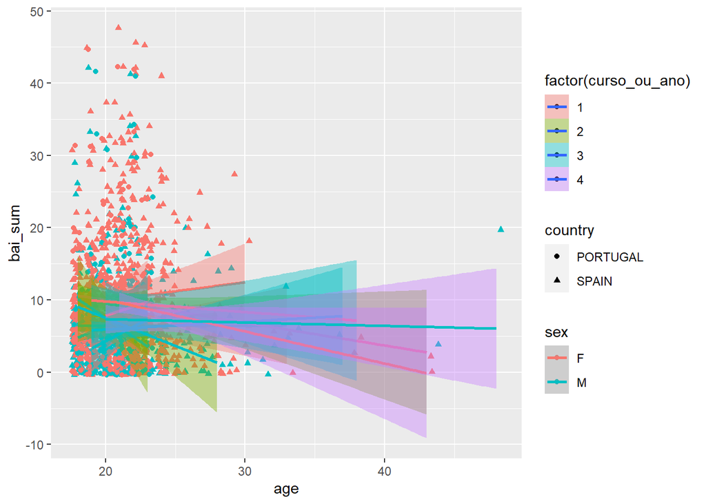

```r
dataset %>%
  filter(!is.na(sex), !is.na(curso_ou_ano)) %>%
  ggplot(., aes(x = age, y=bai_sum,
                fill = factor(curso_ou_ano),
                color = sex,
                shape = country)) +
  geom_jitter() +
  geom_smooth(method = "lm")
```

# Análises de associação entre variáveis

Muitas vezes, o pesquisador está interessado no estudo ou análise de relações entre variáveis. Nesses casos, ele recorrerá a estatísticas como o teste de qui-quadrado (caso tenha variáveis do tipo nominal ou categórica), coeficiente de correlação de Pearson ou regressão linear quando as variáveis forem contínuas.

## Testes de Qui-Quadrado

O teste de qui-quadrado é uma medida de associação entre variáveis categóricas, das quais só temos a frequência de ocorrência. Existem três tipos de testes de qui-quadrado:

- de aderência: quando se deseja verificar as distribuições de probabilidades de cada categoria de uma variável em relação a um valor teórico esperado.
- de homogeneirdade: quando se deseja verificar se as distribuições das categorias são as mesmas para diferentes subpopulações de interesse.
- de independência: verficiar se duas variáveis categóricas são independentes

Neste caso, vamos fazer uma análise de qui-quadrado de independência, a mais comumumente utilizada, para verificar se há uma associação entre país e sexo dos participantes do banco de dados dataset. O primeiro passo para isso é montar uma tabela de contingência.

### Tabela de Contingência

Nesse caso, vamos usar a função da base `table()` para gerar uma tabela 2 x 3, duas linhas e três colunas, em que as linhas representarão os sexos masculino e feminino, e as colunas representarão os países: Brasil, Portugal e Espanha.

```r
tabcont_sex_country <- table(dataset$sex,dataset$country)
```

O próximo passo é realizar a análise de qui-quadrado em si.

### Análise de qui-quadrado.

```r
# É bom salvá-la em um objeto porque tem mais informações do que as que são mostradas na análise.
options(scipen = 999) # função para tirar a notação científica de potência.
chi_sex_country <- chisq.test(tabcont_sex_country)

# Pressuposto: frequências esperadas > 5
###chi_sex_country$expected
###round(chi_sex_country$expected,0)

# Análise dos resíduos
## Resíduo padronizado ou resíduo de Pearson
###chi_sex_country$residuals

## Resíduo padronizado ajustado (mais usado) -
### Estão padronizados em z.
### Portanto, valores > 1.96 ou < -1.96 são considerados valores significativos para p/ alfa de 5%
### ou seja, cujos resíduos encontrados são maiores do que os esperados.
###chi_sex_country$stdres

# Alguns autores recomendam um ajuste na análise do resíduo em função do tamanho da tabela de contingência
# Assim, novo_sig = 0,05/(n_linhas * n_colunas)
# a nova formula para calcular o índice de significância é:
new_alfa <- 0.05/(nrow(tabcont_sex_country)*ncol(tabcont_sex_country))

# calcular os pontos de corte em z para o novo valor de alfa (new_alfa)
###qnorm(0.05/2)       # valor de z correspondente a um alfa de 5%, que dá o 1,96
###qnorm(new_alfa/2)   # z relativo ao new_alfa: > 2,64 ou < -2,64, para alfa=0,83%
                    # Usar esse valor para avaliar os resíduso padr. ajustados
                    # com o novo valor de z, os resultados continuam significativos.
# uma opção seria calcular o p para todos os resíduos
###options(scipen = 0)
###2*(1-pnorm(abs(chi_sex_country$stdres)))

# Tamanho do efeito
# phi é usado para tabelas 2 x 2
# V de Cramer é usado para tabelas maiores
# usando a função cramer_v() do rstatix
cramer_v(tabcont_sex_country)
```

```
## [1] 0.1576395
```

```r
# A interpretação do V de Cramer depende dos graus de liberdade do teste
# gl = (linhas -1) * (colunas-1)
# Messe caso gl=2 e o V de Cramer corresponde a um tamanho de efeito pequeno (Cohen, 1988).
# O V de Cramer varia de 0 a 1. Valores baixos e altos correspondem a efeitos pequenos e grandes, respectivamente.

# para calcular o phi (tamanho de efeito para tabelas 2 x 2)
# phi(tabela_de_contingência)
```

| Graus.de.Liberdade | Pequeno | Médio | Grande |
| --- | --- | --- | --- |
| 1 | 0.1 | 0.3 | 0.5 |
| 2 | 0.07 | 0.21 | 0.35 |
| 3 | 0.06 | 0.17 | 0.29 |

### Representação gráfica

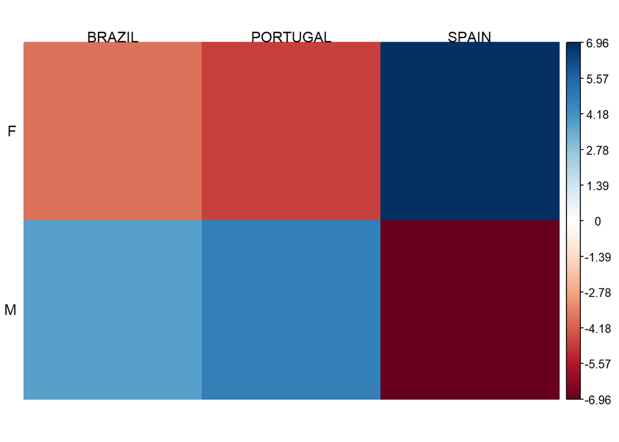

```r
corrplot::corrplot(chi_sex_country$stdres,  # função para representação em cores
                   is.corr = FALSE,         # não se trata de correlações
                   method = "color",        # método para pintar o quadrado todo.
                   tl.col = "black",        # textos na cor preta
                   tl.srt = 0)              # angulação das colunas, 90 é vertical.
```

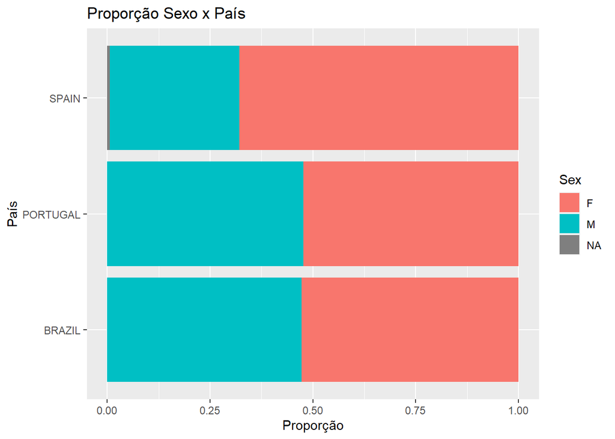

```r
ggplot(dataset, aes(x = country, fill = sex)) +
  geom_bar(position = "fill") +
  coord_flip() +
  labs(title = "Proporção Sexo x País",
       x = "País", y = "Proporção", fill = "Sex")
```

### Exercícios sobre qui-quadrado

1. Calcular o qui-quadrado para verificar as associações entre sexo e ansiedade (bai_class)
2. Calcular o qui-quadrado para verificar as associações entre sexo e depressão (bai_class)

Dica: para que as categorias de ansiedade e depressão sejam mostradas em ordem crescente (mínima, leve, moderada, grave), é necessário informar o R disso por meio do argumento `levels`da função `factor`.

## Coeficientes de correlação (Pearson, Spearman e Kendall)

Quando o interesse do pesquisador é investigar o grau de associação entre variáveis, ele pode empregar o Coeficiente de Correlação de Pearson. Os resultados dessa análise podem variar de -1 a 1. Resultados positivos revelam associação diretamente proporcional entre as variáveis, resultados negativos revelam associação inversamente proporcional entre as variáveis e resultados próximos de zero indicam que não há associação entre as variáveis.  
No entanto, antes de realizar a análise é preciso verificar se os dados atendem aos pressupostos da análise.

### Verificação dos pressupostos para a análise

```r
# verificação de normalidade
options(scipen = 999)
shapiro.test(dataset$bai_sum)
```

```
##
##  Shapiro-Wilk normality test
##
## data:  dataset$bai_sum
## W = 0.84033, p-value < 0.00000000000000022
```

```r
shapiro.test(dataset$bdi_sum)
```

```
##
##  Shapiro-Wilk normality test
##
## data:  dataset$bdi_sum
## W = 0.87586, p-value < 0.00000000000000022
```

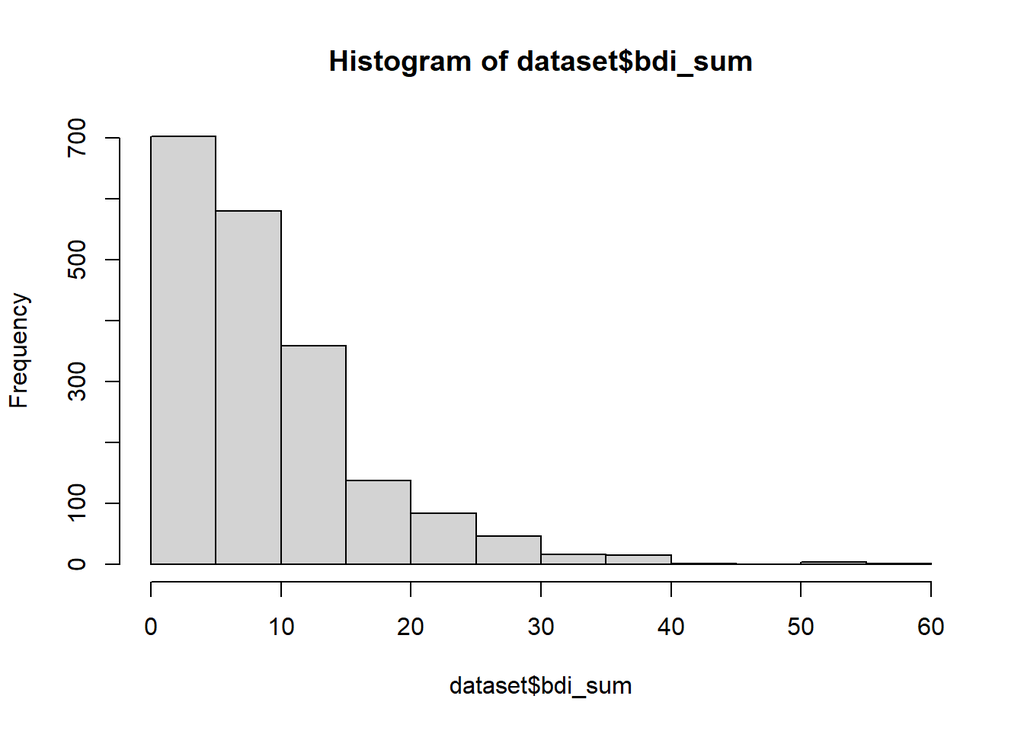

```r
## representação gráfica da normalidade (histograma)
hist(dataset$bdi_sum)
```

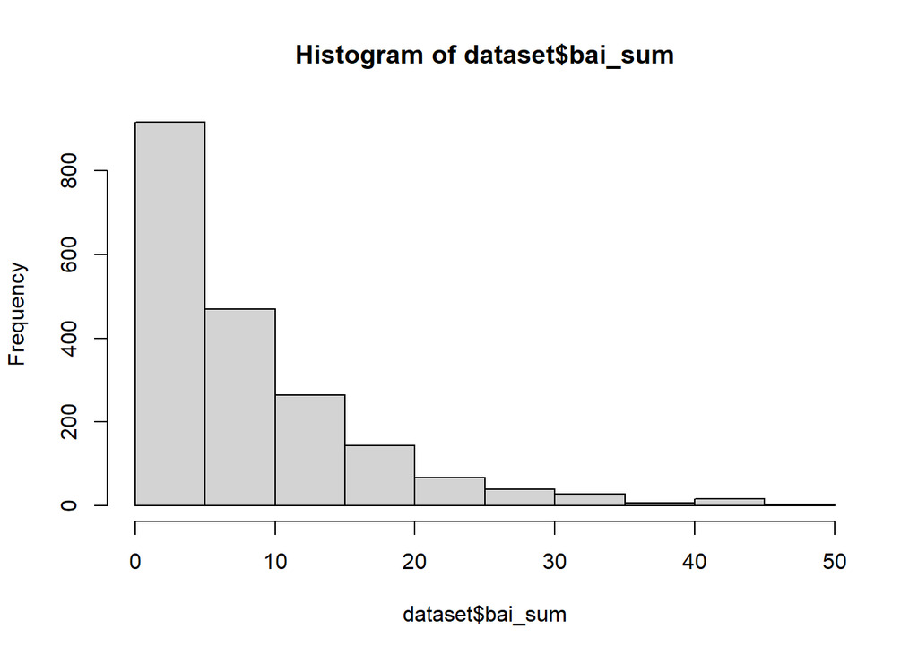

```r
hist(dataset$bai_sum)
```

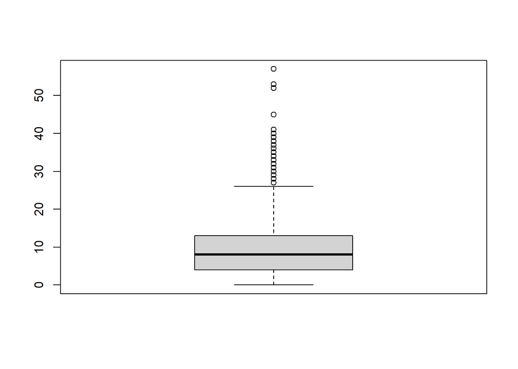

```r
# presença de outliers
boxplot(dataset$bdi_sum)
```

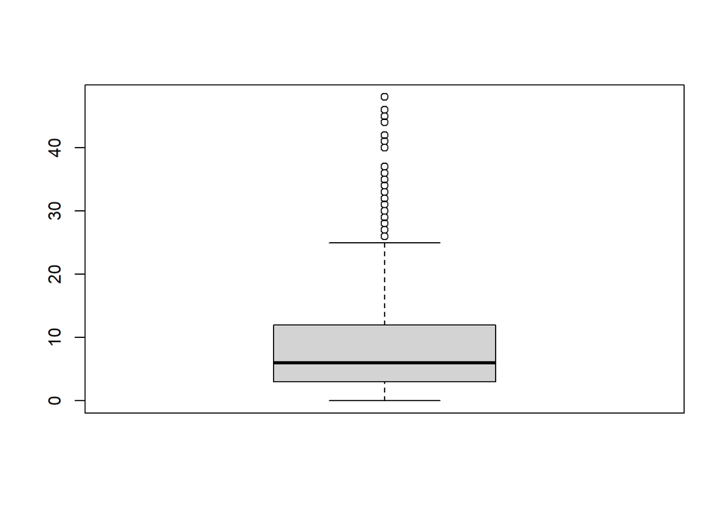

```r
boxplot(dataset$bai_sum)
```

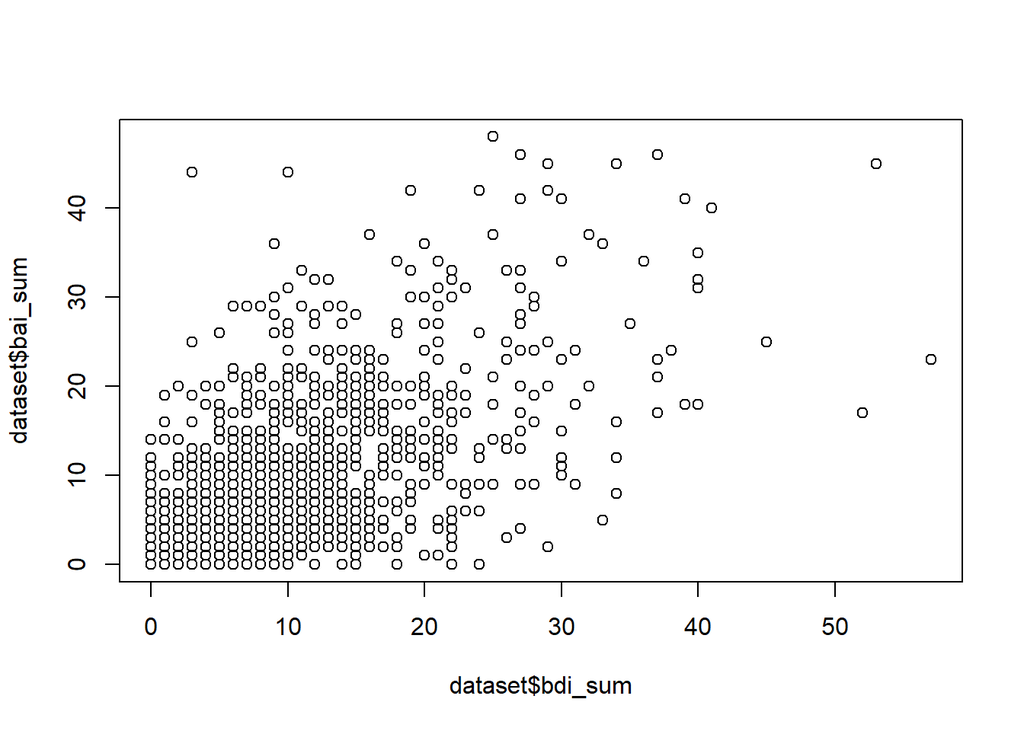

```r
# Relação linear entre as variáveis
plot(dataset$bdi_sum,dataset$bai_sum)
```

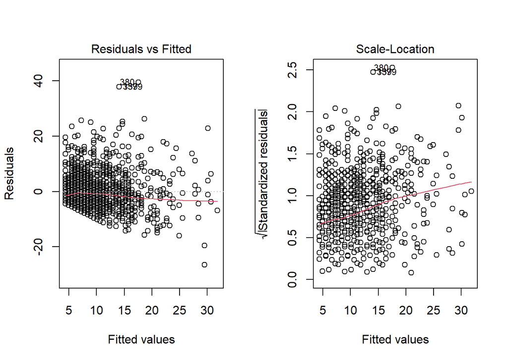

```r
# Análise de resíduos (homocedasticidade)
lm_ans_dep <- lm(bdi_sum ~ bai_sum, dataset)

par(mfrow = c(1,2)) # os números indicam uma linha, duas colunas
plot(lm_ans_dep, which = c(1,3))
```

```r
# os gráficos mostram os resíduos pelos valores previstos.
# o 1º mostra os resíduos brutos e o 2º ow resíduos padronizados
# Em ambos os casos a linha deve estar paralela a x, o que indica relação linear entre as variáveis.
# Em ambos os casos os pontos devem estar homogeneamente distribuídos ao longo da reta, distribuição de pontos igualitária ao longo da curva (homocedasticidade). A variação dos resíduos tem que ser homogênea ao longo da curva.
# Verificação de outliers quando há resíduos acima de 3 ou abaixo de -3
par(mfrow = c(1,1)) # voltar para um gráfico por vez
```

### Correlação simples entre duas variáveis

Usando o dataframe `dataset`, vamos calcular o coeficiente de correlação entre depressão e ansiedade:

```r
# correlação de Pearson (r) com o pacote stats, que é da base do R
options(scipen = 0)
cor.test(dataset$bdi_sum,dataset$bai_sum, method = "pearson") %>% pander()
```

Pearson’s product-moment correlation: `dataset$bdi_sum` and `dataset$bai_sum`

| Test statistic | df | P value | Alternative hypothesis | cor |
| --- | --- | --- | --- | --- |
| 33.08 | 1946 | 8.684e-191 * * * | two.sided | 0.5999 |

```r
# correlação de Spearman (rho)
cor.test(dataset$bdi_sum,dataset$bai_sum, method = "spearman") %>% pander()
```

Spearman’s rank correlation rho: `dataset$bdi_sum` and `dataset$bai_sum`

| Test statistic | P value | Alternative hypothesis | rho |
| --- | --- | --- | --- |
| 522131145 | 1.005e-172 * * * | two.sided | 0.5762 |

```r
# correlação de Kendal (Tau)
cor.test(dataset$bdi_sum,dataset$bai_sum, method = "kendall") %>% pander()
```

Kendall’s rank correlation tau: `dataset$bdi_sum` and `dataset$bai_sum`

| Test statistic | P value | Alternative hypothesis | tau |
| --- | --- | --- | --- |
| 27.07 | 2.312e-161 * * * | two.sided | 0.4298 |

A maioria das vezes, os pesquisadores querem observar as correlações entre mais de duas variáveis. Nesses casos, é necessário criar uma matriz de correlações. Para fazer isso, vamos usar o banco de dados `big_five` e a função `corrplot` do pacote `corrplot`.

### Matriz de correlações

```r
# Importar o dataframe big_five
big_five <- readRDS("big_five.rds")

# obter matriz de correlações com a função cor() do stats, da base do R.
matriz_cor <- cor(big_five[,59:63], method = "pearson")

# obter matriz de correlações com a função corr.test(), do pacote psych
matriz_psych <- corr.test(big_five[,59:63], method = "pearson")

matriz_psych$r
```

```
##            extr        neur       amab        cons        aber
## extr  1.0000000 -0.26172289  0.3345344  0.10686423  0.16694048
## neur -0.2617229  1.00000000 -0.1108833 -0.25871490 -0.09962951
## amab  0.3345344 -0.11088329  1.0000000  0.17686827  0.11764182
## cons  0.1068642 -0.25871490  0.1768683  1.00000000  0.08735862
## aber  0.1669405 -0.09962951  0.1176418  0.08735862  1.00000000
```

```r
matriz_psych$p
```

```
##               extr          neur          amab          cons          aber
## extr  0.000000e+00 3.055131e-305  0.000000e+00  1.059493e-50 1.966369e-122
## neur 3.394590e-306  0.000000e+00  2.199220e-54 4.248986e-298  2.210051e-44
## amab  0.000000e+00  5.498050e-55  0.000000e+00 1.889515e-137  5.168774e-61
## cons  3.531645e-51 5.311233e-299 2.699307e-138  0.000000e+00  1.025047e-34
## aber 3.277282e-123  1.105025e-44  1.033755e-61  1.025047e-34  0.000000e+00
```

```r
matriz_psych$stars %>% pander()
```

|  | extr | neur | amab | cons | aber |
| --- | --- | --- | --- | --- | --- |
| **extr** | 1*** | -0.26*** | 0.33*** | 0.11*** | 0.17*** |
| **neur** | -0.26*** | 1*** | -0.11*** | -0.26*** | -0.1*** |
| **amab** | 0.33*** | -0.11*** | 1*** | 0.18*** | 0.12*** |
| **cons** | 0.11*** | -0.26*** | 0.18*** | 1*** | 0.09*** |
| **aber** | 0.17*** | -0.1*** | 0.12*** | 0.09*** | 1*** |

```r
# matriz de correlações com linhas e colunas diferentes
matriz1 <- corr.test(big_five[,59:63], big_five[,3], method = "pearson")
matriz1$r
```

```
##              [,1]
## extr  0.012262268
## neur  0.005804270
## amab -0.008407732
## cons  0.004411491
## aber  0.007866135
```

```r
matriz1$p
```

```
##            [,1]
## extr 0.08509186
## neur 0.41506313
## amab 0.23776310
## cons 0.53562358
## aber 0.26935723
```

```r
matriz1$stars %>% pander() # esse tipo de matriz não dá pra plotar.
```

| **extr** | 0.01 |
| --- | --- |
| **neur** | 0.01 |
| **amab** | -0.01 |
| **cons** | 0 |
| **aber** | 0.01 |

### Representação gráfica das correlações

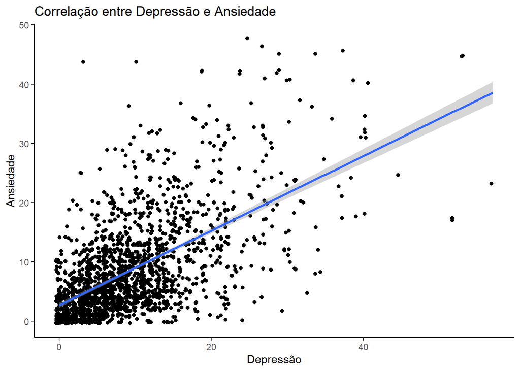

```r
ggplot(dataset, aes(x=bdi_sum,y=bai_sum)) +
  geom_jitter() +
  geom_smooth(method = "lm") +
  labs(title ="Correlação entre Depressão e Ansiedade",
       x = "Depressão",
       y = "Ansiedade") +
  theme_classic()
```

```r
# adicionar informações sobre a curva de regressão

summary(lm_ans_dep) # esse linear model foi rodado no chunk acima
```

```
##
## Call:
## lm(formula = bdi_sum ~ bai_sum, data = dataset)
##
## Residuals:
##     Min      1Q  Median      3Q     Max
## -26.537  -3.945  -0.950   2.768  39.476
##
## Coefficients:
##             Estimate Std. Error t value Pr(>|t|)
## (Intercept)  4.36700    0.20320   21.49   <2e-16 ***
## bai_sum      0.57206    0.01729   33.08   <2e-16 ***
## ---
## Signif. codes:  0 '***' 0.001 '**' 0.01 '*' 0.05 '.' 0.1 ' ' 1
##
## Residual standard error: 6.192 on 1946 degrees of freedom
##   (9 observations deleted due to missingness)
## Multiple R-squared:  0.3599, Adjusted R-squared:  0.3596
## F-statistic:  1094 on 1 and 1946 DF,  p-value: < 2.2e-16
```

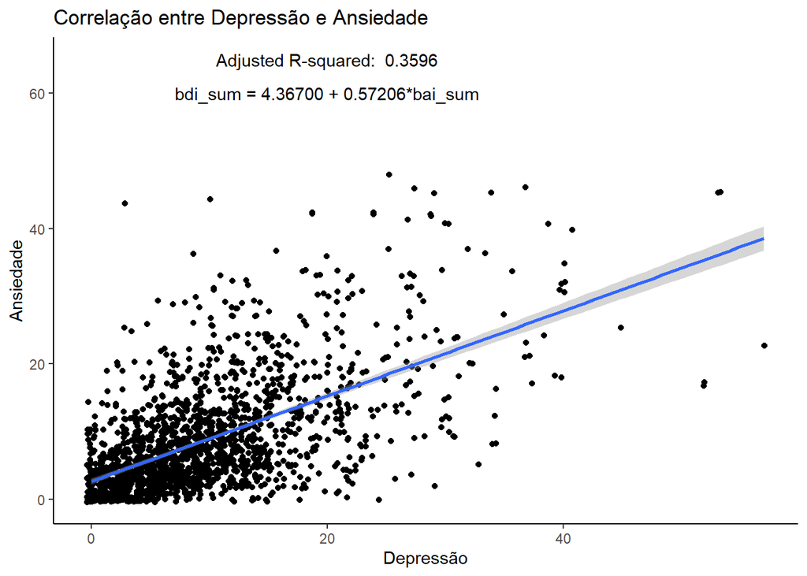

```r
ggplot(dataset, aes(x=bdi_sum,y=bai_sum)) +
  geom_jitter() +
  geom_smooth(method = "lm") +
  labs(title ="Correlação entre Depressão e Ansiedade",
       x = "Depressão",
       y = "Ansiedade") +
  theme_classic() +
  annotate("text",x=20,y=65,label="Adjusted R-squared:  0.3596") +
  annotate("text",x=20,y=60,label="bdi_sum = 4.36700 + 0.57206*bai_sum")
```

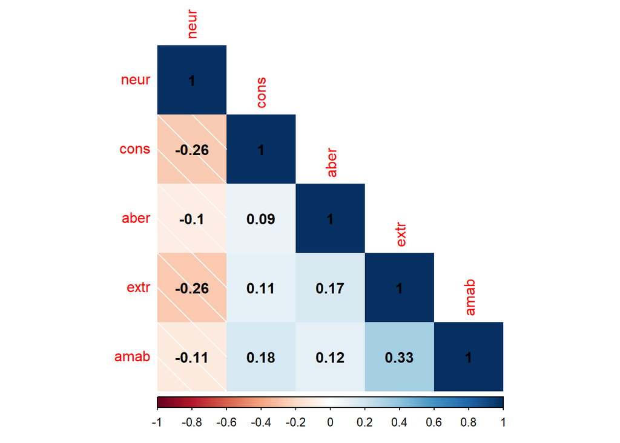

```r
# matriz de correlações usando o corrplot
corrplot::corrplot(matriz_psych$r,
                   method = "shade",
                   type = "lower",
                   order = "hclust",
                   addCoef.col = TRUE)
```

```r
# opções de método: "circle", "square", "ellipse", "number", "shade", "color", "pie
# opções de tipo: "lower", "upper", "full"
# opção de ordem: "hclust"- organiza as correlações hierarquicamente
#                 "original" - ordem das variáveis no banco
#                 "AOE" - angular order of eigenvectors
#                 "alphabet" - ordem alfabética
```

### Exercícios sobre correlação

Baixe o banco de dados [rwas_us](https://docs.google.com/spreadsheets/d/1SNsFa2wRxIvSvA4wVsZz_lkKDNry1WbfjwUkgrZf0k8/edit?usp=sharing), que foi empregada em um estudo sobre autoritarismo conservador, e cole-o no mesmo diretório em que você está salvando seus arquivos para este estudo. Para mais informações sobre as variáveis desse banco de dados, baixe também [este arquivo](https://docs.google.com/document/d/1oOXxYNLe7nd8kkK7QyOKu_2KiDqfO-wuyDuKbB17iz0/edit?usp=sharing). Importe esse banco de dados para o R. Note que ele está no formato csv. Em seguida, use esse banco de dados para realizar os exercício abaixo.

Calcule as correlações (r) e os índices de significância (p) entre os cinco grandes fatores de personalidade (extr, neur, amab, cons e aber).

Calcule as correlações (r) e os índices de significância (p) dos cinco grandes fatores de personalidade (extr, neur, amab, cons e aber) com raciocínio verbal (rv) e autoritarismo (auth), mas expresse os resultados com os traços de personalidade nas linhas e o rv e o auth nas colunas.

Faça um gráfico de pontos para cada par de correlações entre cinco grandes fatores.

Faça um gráfico de calor (heat map) para as correlações entre os cinco grandes fatores.

## Regressão Linear Múltipla

### Carregamento dos pacotes e importação do banco de dados

```r
if(!require(car)) install.packages("car")
if(!require(lmtest)) install.packages("lmtest")
if(!require(ggpubr)) install.packages("ggpubr")
if(!require(QuantPsyc)) install.packages("QuantPsyc")
if(!require(scatterplot3d)) install.packages("scatterplot3d")

library(car)
library(lmtest)
library(ggpubr)
library(QuantPsyc)
library(scatterplot3d)
```

### Análise dos pressupostos

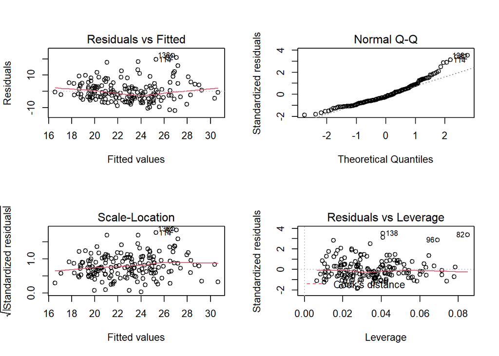

```r
# selecionar os participantes brasileiros do df big_five.

big_five_BR <- big_five %>% filter(país == "BR")

# rodando a regressão (usando a função lm() do pacote stats (básico do R)
# lm vem de linear model

mod <- lm(idade ~ extr+neur+amab+cons+aber, # big-five predizendo idade
          data=big_five_BR,                 # onde estão os dados
          na.action = na.omit)              # ignorar NAs

## Análise dos pressupostos
par(mfrow = c(2,2))
plot(mod)
```

```r
### O primeiro gráfico permite avaliar a linearidade. A linha vermelha tem que estar aproximadamente horizontal para o modelo ser linear.
### O segundo gráfico permite verificar se os resíduos apresentam distribuição normal (Q-Q plot). No eixo y os resíduos encontrados e no eixo x os resíduos que seriam esperados caso a distribuição fosse de fato normal. O esperado é que os pontos caiam sobre a linha pontilhada.
### O terceiro gráfico avalia homocedasticidade. Para que haja homocedasticidade (desejável) os pontos têm que estar distribuídos aleatoriamente pelo retângulo do gráfico e não formando um triângulo. Ou seja, os resíduos têm que ser aleatórios e não correlacionados entre si.
### No quarto gráfico é possível verificar a existência de outliers e pontos influentes. Caso existam outliers haverá pontos para fora da linha pontilhada vermelha. Os resíduos padronizados devem estar entre -3 e +3 (eixo y).

par(mfrow = c(1,1))   # voltar para 1 gráfico por página.

## normalidade dos resíduos usando o pacote stats
options(scipen = 999)
shapiro.test(mod$residuals)
```

```
##
##  Shapiro-Wilk normality test
##
## data:  mod$residuals
## W = 0.93459, p-value = 0.0000003879
```

```r
## Outliers nos resíduos
summary(rstandard(mod)) # os resultados devem estar entre -3 e +3
```

```
##      Min.   1st Qu.    Median      Mean   3rd Qu.      Max.
## -1.876026 -0.668328 -0.200409  0.000536  0.475158  3.521343
```

```r
## Teste de Durbin-Watson
durbinWatsonTest(mod)
```

```
##  lag Autocorrelation D-W Statistic p-value
##    1       0.1207524      1.744514   0.102
##  Alternative hypothesis: rho != 0
```

```r
### não há autocorrelação entre os resíduos quando o valor da estatística está próximo a 2 (entre 1,5 e 2,5, ou entre 1 e 3)

## Homocedasticidade (Breusch-Pagan) ou homogeneidade das variâncias
bptest(mod)   # o valor de p > 0,05 indica que há homocedasticidade
```

```
##
##  studentized Breusch-Pagan test
##
## data:  mod
## BP = 10.919, df = 5, p-value = 0.053
```

```r
## Ausência de multicolinearidade
names(big_five_BR)
```

```
##  [1] "id"      "raça"    "idade"   "ing_nat" "gênero"  "mão_dom" "fonte"
##  [8] "país"    "E1"      "E2"      "E3"      "E4"      "E5"      "E6"
## [15] "E7"      "E8"      "E9"      "E10"     "N1"      "N2"      "N3"
## [22] "N4"      "N5"      "N6"      "N7"      "N8"      "N9"      "N10"
## [29] "A1"      "A2"      "A3"      "A4"      "A5"      "A6"      "A7"
## [36] "A8"      "A9"      "A10"     "C1"      "C2"      "C3"      "C4"
## [43] "C5"      "C6"      "C7"      "C8"      "C9"      "C10"     "O1"
## [50] "O2"      "O3"      "O4"      "O5"      "O6"      "O7"      "O8"
## [57] "O9"      "O10"     "extr"    "neur"    "amab"    "cons"    "aber"
```

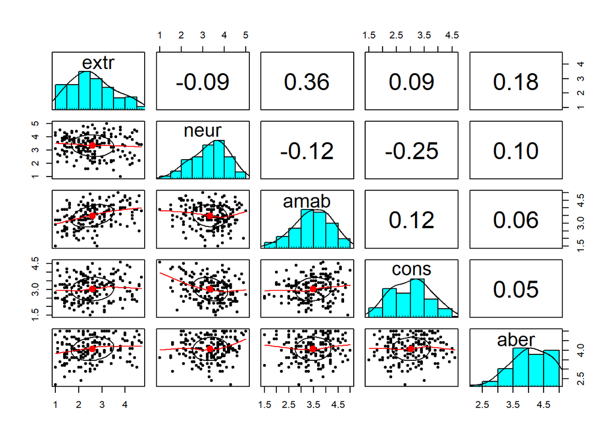

```r
pairs.panels(big_five_BR[,59:63]) # há multicolinearidade quando r > 0.9
```